# Redes Sociales y Productividad Laboral

¿Cuánto explica la satisfacción laboral la productividad real?

Patricia Angulo · Pía Fuentes · Martín Salazar · Benjamín Veliz

Junio 2026

# 1 Introducción

El uso de redes sociales forma parte del cotidiano de trabajadores y estudiantes. Existe la percepción generalizada de que mayor tiempo en redes sociales implica menor productividad. Este proyecto busca cuantificar esa relación mediante un modelo de regresión lineal múltiple (MLR), y compararlo con un árbol de decisión como segundo modelo de referencia.

**Variable objetivo (Y):** `actual_productivity_score` — productividad real del individuo, medida en una escala continua. Se eligió esta variable por sobre `perceived_productivity_score` porque refleja el output real del individuo, independiente de su estado de ánimo o autoestima. Ambas variables tienen una correlación de r > 0.9, pero la productividad real es más relevante para la toma de decisiones organizacionales.

**Pregunta central:** ¿Qué variables predicen mejor la productividad real, y con qué magnitud?

**Decisión que apoya el análisis:** ¿Vale la pena intervenir en la satisfacción laboral para mejorar la productividad, en lugar de restringir el uso de redes sociales?

# 2 Objetivos del Proyecto

## 2.1 Objetivos propuestos

El proyecto fue planteado con tres niveles de entregables:

### 2.1.1 Must accomplish (obligatorios)

1. **Preprocesamiento y selección de variables:** Imputar valores faltantes, codificar variables categóricas e identificar predictores relevantes mediante análisis de correlaciones. *Completado.*
2. **Ajustar un modelo de regresión lineal múltiple:** Entrenar un MLR sobre datos de entrenamiento (split 80/20) con las variables seleccionadas. *Completado.*
3. **Interpretar coeficientes y evaluar desempeño:** Reportar coeficientes, p-values, intervalos de confianza al 95%, R², RMSE y MAE sobre el conjunto de prueba. *Completado.*

### 2.1.2 Expected objectives (esperados)

1. **Evaluar supuestos de la regresión lineal:** Verificar linealidad, homocedasticidad, normalidad de residuos y observaciones influyentes mediante gráficos diagnósticos. *Completado — leve desviación en colas del Q-Q Plot, no crítica.*
2. **Identificar variables con mayor impacto:** Determinar qué predictores explican mejor la productividad real. *Completado — `job_satisfaction_score` es el predictor dominante (r = 0.81).*
3. **Comparar con un modelo benchmark:** Evaluar el MLR contra un modelo nulo y un árbol de decisión (rpart). *Completado.*

### 2.1.3 Desired objectives (deseados)

1. **Comparar productividad percibida vs real:** Evaluar si los mismos predictores funcionan igual para ambas variables dependientes. *Completado — se verificó que `perceived_productivity_score` y `actual_productivity_score` tienen r > 0.9. `perceived` fue descartada como predictor por multicolinealidad extrema.*
2. **Comparar con otros métodos predictivos simples:** Entrenar un árbol de decisión (rpart) con los mismos predictores y comparar métricas. *Completado — el árbol obtiene RMSE = 1.061, prácticamente idéntico al MLR (RMSE = 1.065).*

# 3 Datos

## 3.1 Dataset

Se utilizó el dataset **Social Media vs Productivity** obtenido de Kaggle ([enlace](https://www.kaggle.com/datasets/mahdimashayekhi/social-media-vs-productivity)), que contiene aproximadamente 30.000 registros simulando comportamientos relacionados con el uso de redes sociales, hábitos y productividad individual.

**Nota importante:** El análisis exploratorio reveló que el dataset es de **origen sintético** — las variables fueron generadas artificialmente, lo que limita la validez externa de los resultados. Esta limitación se discute en la sección de conclusiones.

## 3.2 Instalación y carga de paquetes

```r
# Instalar paquetes si no están disponibles
if (!require(Metrics))    install.packages("Metrics")
if (!require(rpart))      install.packages("rpart")
if (!require(rpart.plot)) install.packages("rpart.plot")

library(Metrics)
library(rpart)
library(rpart.plot)
```

## 3.3 Carga de datos

```r
# Carga el dataset desde el archivo .RData del proyecto
# (este archivo ya contiene el dataset social_media_vs_productivity en el entorno)
load(".RData")

# Renombramos a "bd" para usar a lo largo del notebook
bd <- social_media_vs_productivity
```

## 3.4 Exploración inicial

```r
# Dimensiones del dataset
cat("Filas:", nrow(bd), "| Columnas:", ncol(bd), "\n")
```

```
## Filas: 30000 | Columnas: 19
```

```r
# Primeras 6 filas
head(bd)
```

```
##   age gender   job_type daily_social_media_time social_platform_preference
## 1  56   Male Unemployed                4.180940                   Facebook
## 2  46   Male     Health                3.249603                    Twitter
## 3  32   Male    Finance                      NA                    Twitter
## 4  60 Female Unemployed                      NA                   Facebook
## 5  25   Male         IT                      NA                   Telegram
## 6  38   Male    Finance                1.512568                    Twitter
##   number_of_notifications work_hours_per_day perceived_productivity_score
## 1                      61           6.753558                     8.040464
## 2                      59           9.169296                     5.063368
## 3                      57           7.910952                     3.861762
## 4                      59           6.355027                     2.916331
## 5                      66           6.214096                     8.868753
## 6                      50           6.429312                           NA
##   actual_productivity_score stress_level sleep_hours screen_time_before_sleep
```

[output cut: 27 more lines]

```r
# Conteo de valores faltantes por columna
na_counts <- colSums(is.na(bd))
na_counts[na_counts > 0]
```

```
##      daily_social_media_time perceived_productivity_score
##                         2765                         1614
##    actual_productivity_score                 stress_level
##                         2365                         1904
##                  sleep_hours     screen_time_before_sleep
##                         2598                         2211
##       job_satisfaction_score
##                         2730
```

# 4 Preprocesamiento

## 4.1 Imputación de valores faltantes

```r
# Reemplaza NA en variables numéricas con la media de cada columna
bd[] <- lapply(bd, function(x) {
  if (is.numeric(x)) {
    x[is.na(x)] <- mean(x, na.rm = TRUE)
  }
  return(x)
})

# Verificación: no deben quedar NAs en columnas numéricas
cat("NAs restantes en columnas numéricas:",
    sum(sapply(bd[, sapply(bd, is.numeric)], is.na)), "\n")
```

```
## NAs restantes en columnas numéricas: 0
```

## 4.2 Análisis exploratorio de correlaciones

Antes de seleccionar variables, calculamos la correlación de todas las variables numéricas con la variable dependiente. Este paso es fundamental para justificar la selección de predictores.

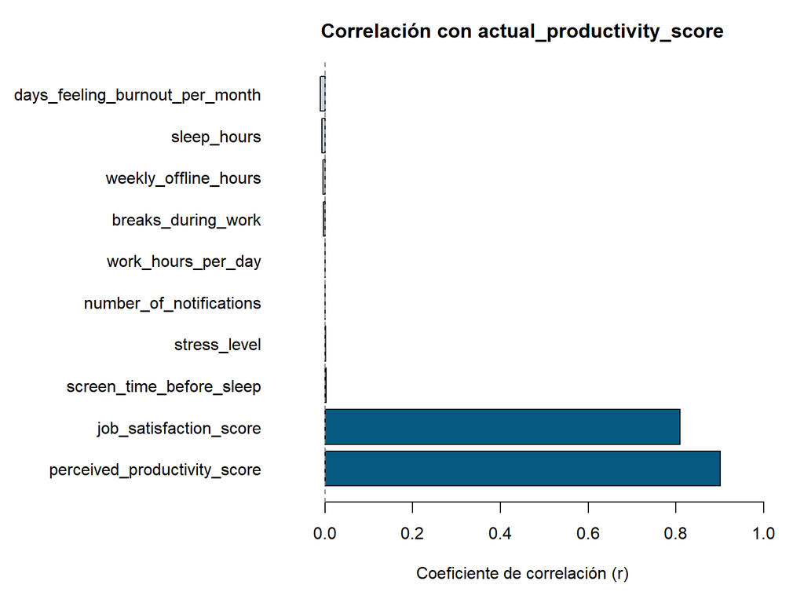

```r
vars_numericas <- c("actual_productivity_score", "perceived_productivity_score",
                    "job_satisfaction_score", "stress_level", "sleep_hours",
                    "work_hours_per_day", "number_of_notifications",
                    "days_feeling_burnout_per_month", "weekly_offline_hours",
                    "screen_time_before_sleep", "breaks_during_work")

mat_cor <- cor(bd[, vars_numericas], use = "complete.obs")

# Extraemos la correlación de cada variable con actual_productivity_score
cor_con_y <- sort(mat_cor[, "actual_productivity_score"], decreasing = TRUE)
cor_con_y <- cor_con_y[names(cor_con_y) != "actual_productivity_score"]

# Visualización
par(mar = c(5, 14, 3, 2))
barplot(
  cor_con_y,
  horiz    = TRUE,
  las      = 1,
  col      = ifelse(abs(cor_con_y) > 0.1, "#065A82", "#CBD5E1"),
  main     = "Correlación con actual_productivity_score",
  xlab     = "Coeficiente de correlación (r)",
  xlim     = c(-0.1, 1)
)
abline(v = 0, lty = 2, col = "gray50")
```

## 4.3 Codificación de variable categórica

```r
# Al probar job_type completo como factor, solo la categoría "Unemployed" resultó
# estadísticamente significativa. Por esto creamos una dummy binaria más parsimoniosa.
bd$es_desempleado <- ifelse(bd$job_type == "Unemployed", 1, 0)

cat("Distribución de es_desempleado:\n")
```

```
## Distribución de es_desempleado:
```

```r
table(bd$es_desempleado)
```

```
##
##     0     1
## 25042  4958
```

## 4.4 División train / test

```r
set.seed(123)  # Semilla para reproducibilidad

idx   <- sample(1:nrow(bd), size = 0.8 * nrow(bd))
train <- bd[idx, ]
test  <- bd[-idx, ]

cat("Train:", nrow(train), "filas | Test:", nrow(test), "filas\n")
```

```
## Train: 24000 filas | Test: 6000 filas
```

**Justificación del split 80/20:** Con 30.000 registros, el 20% de prueba (6.000 obs.) es suficiente para obtener estimaciones estables de RMSE y MAE, sin sacrificar datos de entrenamiento.

# 5 Modelos

## 5.1 Modelo 1: Regresión Lineal Múltiple (MLR)

La regresión lineal múltiple asume una relación lineal entre los predictores y la variable dependiente. Es el modelo principal por su alta interpretabilidad: cada coeficiente indica el cambio esperado en productividad por cada unidad de cambio en el predictor, manteniendo los demás constantes.

$$\hat{Y} = \beta_0 + \beta_1 \cdot
\text{job\_satisfaction\_score} + \beta_2 \cdot \text{es\_desempleado} +
\varepsilon$$

```r
modelo_mlr <- lm(actual_productivity_score ~ job_satisfaction_score +
                   es_desempleado, data = train)

summary(modelo_mlr)
```

```
##
## Call:
## lm(formula = actual_productivity_score ~ job_satisfaction_score +
##     es_desempleado, data = train)
##
## Residuals:
##     Min      1Q  Median      3Q     Max
## -4.3073 -0.6660  0.0036  0.6850  4.2943
##
## Coefficients:
##                        Estimate Std. Error t value Pr(>|t|)
## (Intercept)            1.349124   0.018377  73.412   <2e-16 ***
## job_satisfaction_score 0.724897   0.003377 214.664   <2e-16 ***
## es_desempleado         0.040455   0.018396   2.199   0.0279 *
## ---
## Signif. codes:  0 '***' 0.001 '**' 0.01 '*' 0.05 '.' 0.1 ' ' 1
##
## Residual standard error: 1.061 on 23997 degrees of freedom
## Multiple R-squared:  0.6576, Adjusted R-squared:  0.6576
## F-statistic: 2.304e+04 on 2 and 23997 DF,  p-value: < 2.2e-16
```

### 5.1.1 Intervalos de confianza al 95%

```r
confint(modelo_mlr, level = 0.95)
```

```
##                              2.5 %     97.5 %
## (Intercept)            1.313103041 1.38514457
## job_satisfaction_score 0.718278392 0.73151624
## es_desempleado         0.004398091 0.07651133
```

**Interpretación de coeficientes:**

- **`job_satisfaction_score` (β = 0.725, p < 2×10⁻¹⁶):** Cada punto adicional de satisfacción laboral se asocia con un aumento de 0.725 puntos en productividad real. Este es el predictor dominante del modelo.
- **`es_desempleado` (β = 0.040, p = 0.028):** Las personas desempleadas tienen, en promedio, 0.040 puntos más de productividad reportada que quienes tienen empleo, controlando por satisfacción laboral. El efecto es pequeño pero estadísticamente significativo.

### 5.1.2 Verificación de supuestos

Los supuestos se verifican sobre una muestra de 500 observaciones para legibilidad de los gráficos. El modelo completo tiene 24.000 puntos, lo que hace ilegibles los plots.

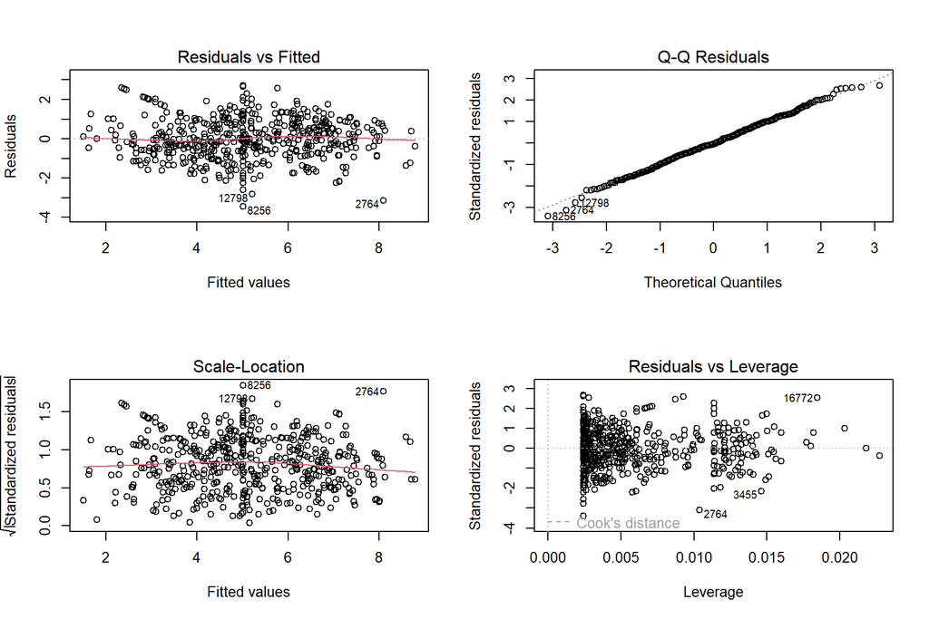

```r
set.seed(123)
datos_pequeños <- train[sample(nrow(train), 500), ]

modelo_muestra <- lm(actual_productivity_score ~ job_satisfaction_score +
                       es_desempleado, data = datos_pequeños)

par(mfrow = c(2, 2))
plot(modelo_muestra)
```

```r
par(mfrow = c(1, 1))
```

### 5.1.3 Métricas en test

```r
pred_mlr <- predict(modelo_mlr, newdata = test)

rmse_mlr <- rmse(test$actual_productivity_score, pred_mlr)
mae_mlr  <- mae(test$actual_productivity_score,  pred_mlr)

cat("RMSE MLR:", round(rmse_mlr, 4), "\n")
```

```
## RMSE MLR: 1.0652
```

```r
cat("MAE  MLR:", round(mae_mlr,  4), "\n")
```

```
## MAE  MLR: 0.8288
```

## 5.2 Modelo 2: Árbol de Decisión (rpart)

El árbol de decisión particiona el espacio de predictores en regiones y predice la media de Y en cada región. No asume linealidad, lo que lo hace útil como benchmark: si el árbol supera ampliamente al MLR, indicaría relaciones no lineales que el MLR no captura.

```r
modelo_arbol <- rpart(
  actual_productivity_score ~ job_satisfaction_score + es_desempleado,
  data    = train,
  method  = "anova",       # Regresión (Y continua)
  control = rpart.control(cp = 0.001)
)

# Tabla de complejidad: muestra el error de validación cruzada por nivel de poda
printcp(modelo_arbol)
```

```
##
## Regression tree:
## rpart(formula = actual_productivity_score ~ job_satisfaction_score +
##     es_desempleado, data = train, method = "anova", control = rpart.control(cp = 0.001))
##
## Variables actually used in tree construction:
## [1] job_satisfaction_score
##
## Root node error: 78862/24000 = 3.2859
##
## n= 24000
##
##           CP nsplit rel error  xerror      xstd
## 1  0.4631437      0   1.00000 1.00011 0.0068587
## 2  0.0994404      1   0.53686 0.54242 0.0047679
## 3  0.0522901      2   0.43742 0.43786 0.0037592
## 4  0.0152740      3   0.38513 0.38875 0.0035857
## 5  0.0086163      4   0.36985 0.37137 0.0035380
## 6  0.0077298      5   0.36124 0.36190 0.0034883
## 7  0.0076819      6   0.35351 0.35773 0.0034528
## 8  0.0023073      7   0.34582 0.34859 0.0034080
## 9  0.0020547      8   0.34352 0.34669 0.0034056
## 10 0.0016308      9   0.34146 0.34461 0.0034036
## 11 0.0013348     10   0.33983 0.34361 0.0034005
## 12 0.0010000     11   0.33850 0.34249 0.0033975
```

### 5.2.1 Poda del árbol

```r
# Selecciona el cp que minimiza el error de validación cruzada
cp_optimo <- modelo_arbol$cptable[which.min(modelo_arbol$cptable[, "xerror"]), "CP"]
cat("CP óptimo:", cp_optimo, "\n")
```

```
## CP óptimo: 0.001
```

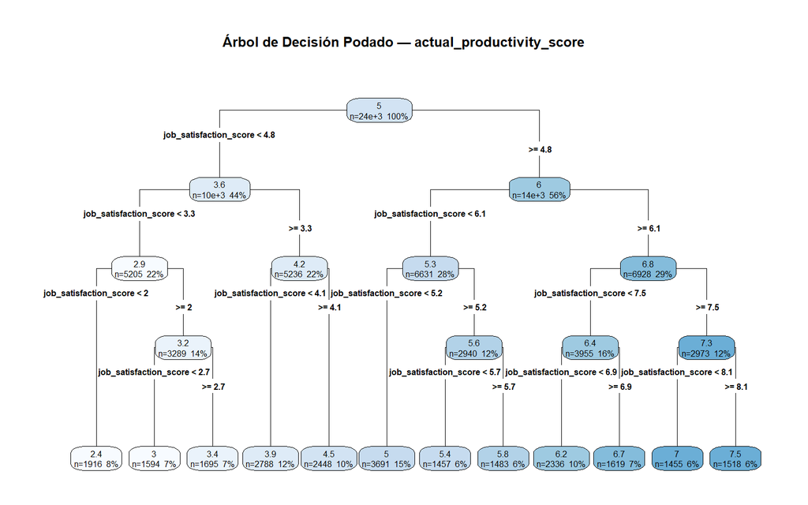

```r
# Poda para evitar sobreajuste
modelo_arbol_podado <- prune(modelo_arbol, cp = cp_optimo)

rpart.plot(modelo_arbol_podado, type = 4, extra = 101,
           main = "Árbol de Decisión Podado — actual_productivity_score")
```

**Observación importante:** El árbol utilizó únicamente `job_satisfaction_score` en sus particiones — `es_desempleado` no fue seleccionada. Esto refuerza que `job_satisfaction_score` es el predictor dominante.

```r
pred_arbol <- predict(modelo_arbol_podado, newdata = test)

rmse_arbol <- rmse(test$actual_productivity_score, pred_arbol)
mae_arbol  <- mae(test$actual_productivity_score,  pred_arbol)

cat("RMSE Árbol:", round(rmse_arbol, 4), "\n")
```

```
## RMSE Árbol: 1.0611
```

```r
cat("MAE  Árbol:", round(mae_arbol,  4), "\n")
```

```
## MAE  Árbol: 0.8298
```

## 5.3 Baseline (Modelo Nulo)

El modelo nulo predice siempre la media de Y del conjunto de entrenamiento. Es el piso mínimo que cualquier modelo debe superar para ser útil.

```r
baseline      <- rep(mean(train$actual_productivity_score), nrow(test))
rmse_baseline <- rmse(test$actual_productivity_score, baseline)
mae_baseline  <- mae(test$actual_productivity_score,  baseline)

cat("RMSE Baseline:", round(rmse_baseline, 4), "\n")
```

```
## RMSE Baseline: 1.787
```

```r
cat("MAE  Baseline:", round(mae_baseline,  4), "\n")
```

```
## MAE  Baseline: 1.4697
```

# 6 Resultados y Comparación

## 6.1 Tabla comparativa

```r
resultados <- data.frame(
  Modelo  = c("Baseline (modelo nulo)", "Árbol de decisión (rpart)", "MLR"),
  RMSE    = round(c(rmse_baseline, rmse_arbol, rmse_mlr), 4),
  MAE     = round(c(mae_baseline,  mae_arbol,  mae_mlr),  4),
  `Reducción RMSE vs Baseline` = paste0(
    round((1 - c(rmse_baseline, rmse_arbol, rmse_mlr) / rmse_baseline) * 100, 1), "%"
  )
)

print(resultados, row.names = FALSE)
```

```
##                     Modelo   RMSE    MAE Reducción.RMSE.vs.Baseline
##     Baseline (modelo nulo) 1.7870 1.4697                         0%
##  Árbol de decisión (rpart) 1.0611 0.8298                      40.6%
##                        MLR 1.0652 0.8288                      40.4%
```

## 6.2 Gráfico comparativo

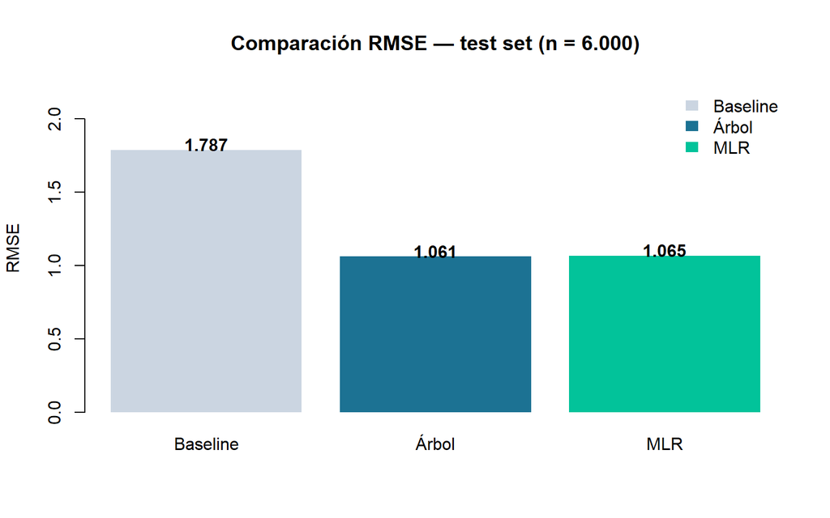

```r
modelos <- c("Baseline", "Árbol", "MLR")
rmses   <- c(rmse_baseline, rmse_arbol, rmse_mlr)
colores <- c("#CBD5E1", "#1C7293", "#02C39A")

bp <- barplot(
  rmses,
  names.arg = modelos,
  col       = colores,
  main      = "Comparación RMSE — test set (n = 6.000)",
  ylab      = "RMSE",
  ylim      = c(0, max(rmses) * 1.25),
  border    = NA
)

text(x      = bp,
     y      = rmses + 0.04,
     labels = round(rmses, 3),
     cex    = 1.0,
     font   = 2)

legend("topright",
       legend  = modelos,
       fill    = colores,
       border  = NA,
       bty     = "n")
```

# 7 Conclusiones

## 7.2 Limitaciones

- **Dataset sintético:** Las variables fueron generadas artificialmente, lo que limita la validez externa de los resultados. El patrón de correlaciones casi nulas entre la mayoría de variables y la productividad es una señal clara de esto.
- **Un solo predictor dominante:** El modelo depende casi exclusivamente de `job_satisfaction_score`. En datos reales, se esperaría un conjunto más diverso de predictores significativos.
- **Leve incumplimiento de normalidad:** Los residuos presentan colas más pesadas de lo normal (leptocurtosis), aunque no crítico dado el tamaño muestral.

## 7.3 Recomendación

Con base en los resultados, **intervenir en la satisfacción laboral tiene mayor impacto esperado sobre la productividad que restringir el uso de redes sociales**. Esta conclusión debe replicarse con datos observacionales reales antes de tomar decisiones organizacionales, dado el origen sintético del dataset utilizado.

*EII 4220 Introducción a la Ciencia de Datos — Pontificia Universidad Católica de Valparaíso*  
*Junio 2026*